# Analisando projetos de desenvolvimento de software

Veruska Borges Santos - FPCC2, UFCG

O objetivo deste relatório é analisar, utilizando a linguagem R, um conjunto de projetos de desenvolvimento de software e identificar características de projeto relacionadas ao processo do desenvolvimento, a linguagem de programação e ao tamanho da equipe de colaboradores, por exemplo.

## Pré-processamento dos dados

Importando biblioteca do R a ser usada para ler os dados e manipulá-los.

```r
library(tidyverse)
```

Carregando os dados, já processados, que serão analisados.

```r
projetos = read.csv(here::here("data/projetos.csv"))
```

Abaixo, removemos projetos que não queremos analisar, por exemplo, aqueles cuja linguagem dominante é Javascript, somando 4. Também removemos projetos com equipe de tamanho 0, que totalizaram 1 projeto na base de dados, caracterizado como um registro inconsistente ao analisar outros atributos como o período de atividade e total de commits por mês.

```r
projetos = projetos %>%
    filter(lang != "javascript" & (team != 0))
```

## Analisando a quantidade de colaboradores por projeto, que usam travis, em Java e em Ruby, nesses dados

Criando um gráfico que exibe o tamanho das equipes dos projetos de cada linguagem e a sua frequência. A posição das barras (eixo x) representa a quantidade de colaboradores, na escala logarítmica. A altura das barras (eixo y) representa a quantidade de projetos que possuem a determinada quantidade de colaboradores.

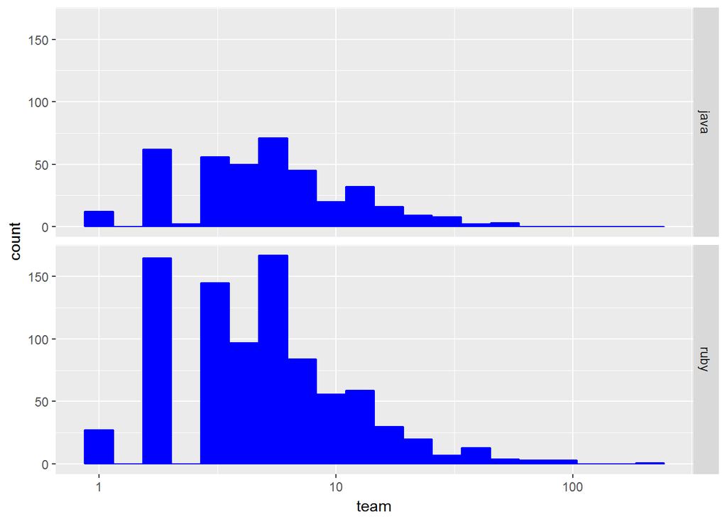

```r
projetos %>%
    ggplot(aes(x = team)) +
    geom_histogram(bins = 20, fill = "blue", color = "blue") +
    facet_grid(lang ~ .) +
    scale_x_log10()
```

## Ao comparar projetos em Java e em Ruby que tenham ao menos 10 contribuidores no time, nos nossos dados, projetos de qual linguagem variam mais na proporção de builds cujo resultado é sucesso?

Filtrando os projetos que têm no mínimo 10 contribuidores.

```r
projetos = projetos %>%
    filter(team >= 10)
```

Existem 244 projetos com ao menos 10 contribuidores. Eles são exibidos abaixo (pontos) com a sua respectiva proporção de buid de sucesso (eixo y). A maioria dos projetos, tanto em Java como em Ruby, possuem mais de 50% de build de sucesso, pois, há poucos pontos abaixo de 0.50 no gráfico abaixo.

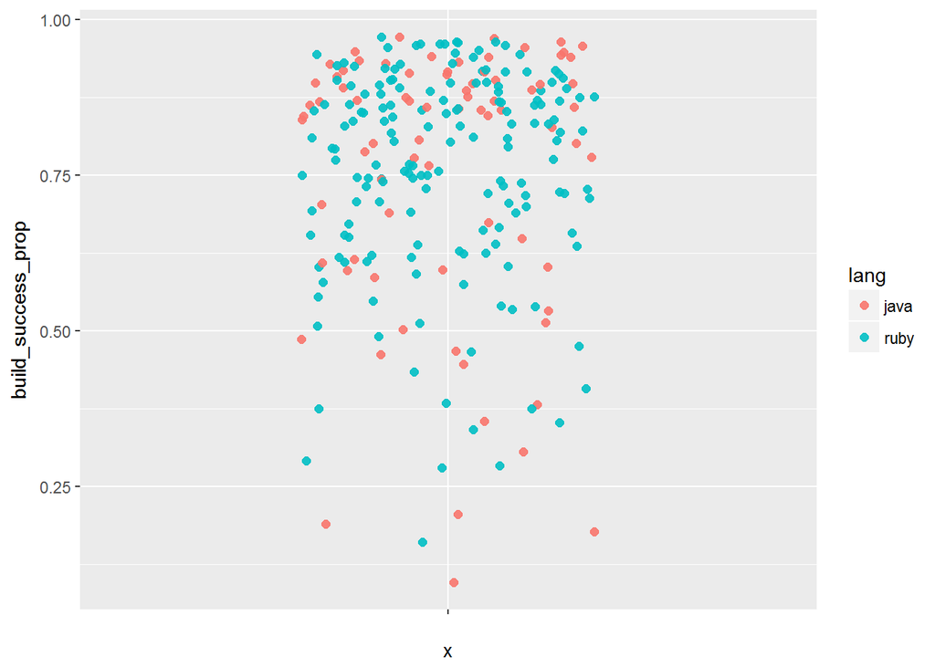

```r
projetos %>%
    ggplot(aes(x = "",
               y = build_success_prop, color = lang)) +
    geom_jitter(alpha = .9, width = .2, size = 2)
```

Há indícios de que os projetos da linguagem Java possuem uma maior variação, devido a distribuição espalhada no gráfico, em torno do eixo y, enquanto os projetos em Ruby estão mais concentrados na parte superior.

O gráfico abaixo facilita a visualização, ao separar as linguagens, e confirma a hipótese de que os projetos Java possuem maior variação na proporção do build de sucesso, pois há projetos (pontos vermelhos) com todos os valores de proporção, ou seja, espalhados por todo o eixo y. Os projetos Ruby possuem a proporção de build de sucesso concentrada entre 50% e 100% e poucos valores fora desse intervalo.

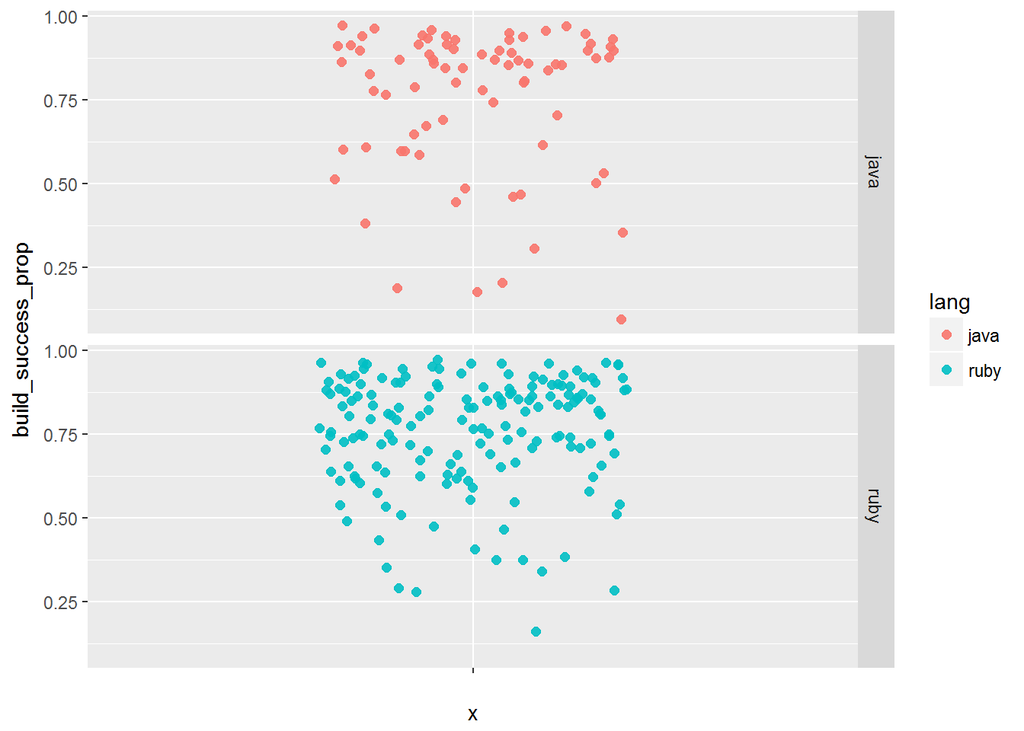

```r
projetos %>%
    ggplot(aes(x = "",
               y = build_success_prop, color = lang)) +
    geom_jitter(alpha = .9, width = .2, size = 2) +
    facet_grid(lang ~ .)
```

Assim, confirmamos através de análises e visualizações dos dados, que as equipes dos projetos em Java e Ruby, disponíveis no Travis, possuem, em geral, entre 3 e 10 colaborares e que, os projetos Java com 10 ou mais colaboradores possuem maior variação na proporção de builds de sucesso, em relação a projetos Ruby.